# 2_Exercise1

Haifaa Alzahrani

11/22/2020

## [Exercise 1](https://misk-data-science.github.io/misk-homl/docs/99x1-portfolio-builder.html)

```r
# Import packages
# Helper packages
library(tidyverse)
```

```r
library(dplyr)     # for data manipulation
library(ggplot2)   # for awesome graphics
#library(corrplot)  # for correlation plot

# Modeling process packages
library(rsample)   # for resampling procedures
library(caret)     # for resampling and model training
#library(h2o)       # for resampling and model training

# Results
library(Metrics)
# Read the dataset
netFlow <- read_csv('Data/IoT_Intrusion_Dataset_2020_Prepared.csv')
# Examine the dataset
#The dimensions
glimpse(netFlow)
```

```
## Rows: 412,510
## Columns: 85
## $ X1                <dbl> 0, 1, 2, 3, 4, 5, 6, 7, 8, 9, 10, 11, 12, 13, 14, 1…
## $ Flow_ID           <chr> "192.168.0.13-192.168.0.16-10000-10101-17", "192.16…
## $ Src_IP            <chr> "192.168.0.13", "222.160.179.132", "192.168.0.16", …
## $ Src_Port          <dbl> 10000, 2179, 52727, 52964, 36763, 41980, 60175, 414…
## $ Dst_IP            <chr> "192.168.0.16", "192.168.0.13", "192.168.0.13", "19…
## $ Dst_Port          <dbl> 10101, 554, 9020, 9020, 1900, 443, 8899, 443, 8899,…
## $ Protocol          <dbl> 17, 6, 6, 6, 17, 6, 17, 6, 17, 6, 6, 6, 6, 17, 17, …
## $ Timestamp         <chr> "25/07/2019 03:25:53 AM", "26/05/2019 10:11:06 PM",…
## $ Flow_Duration     <dbl> 75, 5310, 141, 151, 153, 157, 139, 112, 86, 6799, 5…
## $ Tot_Fwd_Pkts      <dbl> 1, 1, 0, 0, 2, 2, 20, 0, 1, 0, 2, 1, 2, 3, 10, 5, 0…
## $ Tot_Bwd_Pkts      <dbl> 1, 2, 3, 2, 1, 1, 1, 2, 1, 2, 3, 1, 1, 1, 1, 7, 5, …
## $ TotLen_Fwd_Pkts   <dbl> 982, 0, 0, 0, 886, 0, 640, 0, 32, 0, 0, 1441, 2800,…
## $ TotLen_Bwd_Pkts   <dbl> 1430, 0, 2806, 2776, 420, 0, 32, 2896, 32, 0, 4076,…
```

[output cut: 72 more lines]

```r
dim(netFlow)
```

```
## [1] 412510     85
```

```r
set.seed(123)  # for reproducibility
split  <- rsample::initial_split(netFlow, prop = 0.7,
                                 strata = "Label")
netFlow_train  <- rsample::training(split)
netFlow_test   <- rsample::testing(split)
```

### Q1: Assess the distribution of the target

### - Is the response skewed?

### - Does applying a transformation normalize the distribution?

**Ans1**: The categorical target does not follow the normal distribution, so we cannot determine if it is skewed nor apply transformation, [for more info](https://stats.stackexchange.com/questions/129415/how-can-i-determine-if-categorical-data-is-normally-distributed). Consequently, we have to use resample the data or use appropriate metrics for evaluation.

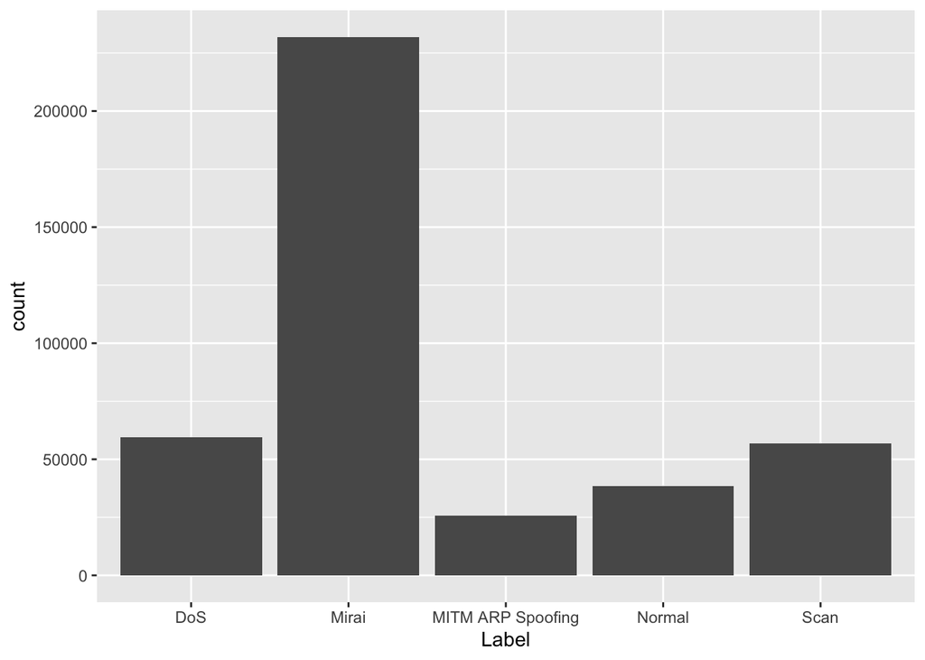

```r
ggplot(netFlow, aes(x = Label)) + geom_bar()
```

### Q2: Assess the dataset for missingness.

### - How many observations have missing values?

### - Plot the missing values. Does there appear to be any patterns to the missing values?

### - How do you think the different imputation approaches would impact modeling results?

**Ans2:** No observations with missing values, so we cannot plot or apply imputation approaches.

```r
sum(is.na(netFlow))
```

```
## [1] 0
```

```r
#library(visdat) # to viz null
#vis_miss(netFlow, cluster = TRUE, warn_large_data = FALSE)
```

### Q3: Assess the variance across the features.

### - Do any features have zero variance?

### - Do any features have near-zero variance?

**Ans3:** Yes, we have 10 features with zero variance, and 26 features with near-zero variance. Most of them are derivative from each flow, thus we will remove them.

```r
caret::nearZeroVar(netFlow_train, saveMetrics = TRUE) %>%
  tibble::rownames_to_column() %>%
  filter(nzv)
```

```
##              rowname   freqRatio percentUnique zeroVar  nzv
## 1    Fwd_Pkt_Len_Std    82.96868  0.4727141759   FALSE TRUE
## 2    Bwd_Pkt_Len_Std    19.88345  0.6458695517   FALSE TRUE
## 3        Flow_Byts/s    44.05730  8.8215737746   FALSE TRUE
## 4        Fwd_IAT_Tot    34.27305  0.5291628284   FALSE TRUE
## 5       Fwd_IAT_Mean    33.91053  1.8562256284   FALSE TRUE
## 6       Bwd_IAT_Mean   110.58122  4.4767590855   FALSE TRUE
## 7        Fwd_IAT_Max    32.52320  0.4959169962   FALSE TRUE
## 8        Fwd_IAT_Min    22.47760  0.3476959946   FALSE TRUE
## 9        Bwd_IAT_Tot    77.52834  3.8059551597   FALSE TRUE
## 10    Bwd_IAT_Mean.1    47.03330  4.1210979436   FALSE TRUE
## 11       Bwd_IAT_Std    82.77614  1.2100097660   FALSE TRUE
## 12       Bwd_IAT_Max    39.71223  3.7640515587   FALSE TRUE
## 13       Bwd_IAT_Min    26.76232  3.5929740475   FALSE TRUE
## 14     Fwd_PSH_Flags     0.00000  0.0003463108    TRUE TRUE
```

[output cut: 22 more lines]

### Q4: Assess the numeric features.

### - Do some features have significant skewness?

### - Do features have a wide range of values that would benefit from standardization?

**Ans4:**

[figure not shown]

```r
# https://drsimonj.svbtle.com/quick-plot-of-all-variables
# https://ggplot2-book.org/facet.html

library(purrr)
library(tidyr)

netFlow_train %>%
  keep(is.numeric) %>% # Keep only numeric columns
  gather() %>% # Convert to key-value pairs
  ggplot(aes(value)) + # Plot the values
    facet_wrap(~ key, scales = "free", nrow = 20) + # In separate panels
    geom_histogram()
```